# 02-assignment_.Rmd

Russell Crutchfield

9/3/2019

## Load the dataset put together by the Census Bureau that summarizes the characteristics of the 3,088 counties in the United States.

```r
load("~/Desktop/Fall 2019/Data Science/scripts/pd.Rdata")
```

## The codebook for this dataset is stored as another dataset, `labels_explain`. The first column in this dataset is variable names, the second column is a full explanation of that variable.

```r
## Full explanation of data in codebook
load("~/Desktop/Fall 2019/Data Science/scripts/pd_lab_explain.Rdata")

#or use View
#View(lab_explain)
```

## Problem Set 2

## 1. Calculate the mean of the outcome.

```r
##Unconditional Average
pd%>%summarize(mean_homeown_rate=mean(homeown_rate,na.rm=TRUE))
```

```
## # A tibble: 1 x 1
##   mean_homeown_rate
##               <dbl>
## 1              72.7
```

```r
## Create a rank variable for homeownership rates- ranked by homeownership rate - called homeown_rank (we will need this for the data visual in question 2.)
pd<-pd%>%mutate(homeown_rank=rank(homeown_rate))
```

## 2. Use your mean as a prediction: Create a new variable that consists of the mean of the outcome.

```r
##Unconditional Average (mean homeowndership rates) as a Predictor:
pd<-pd%>%mutate(mean_homeown_rate=mean(homeown_rate,na.rm=TRUE))
```

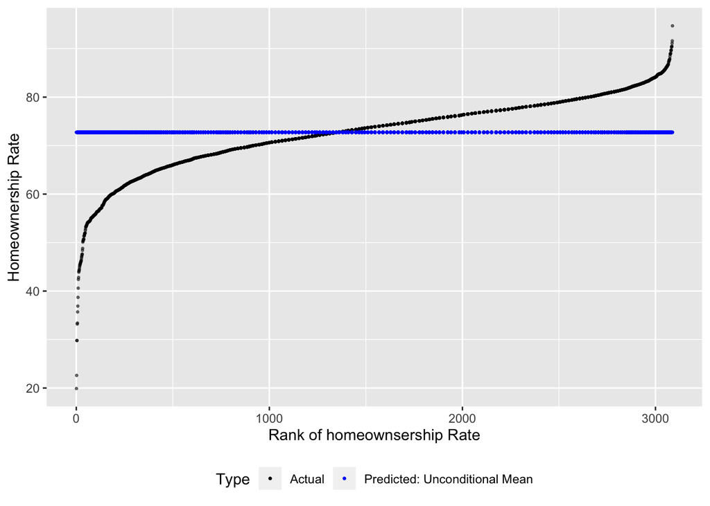

```r
## The code below plots homeownershup rates by county. I ranked counties above by homeownership rate.

##Unconditional - Homeownership rates as a Predictor
pd<-pd%>%mutate(mean_homeown_rate=mean(homeown_rate,na.rm=TRUE))

##Plotting
gg<-ggplot(data=pd,aes(y=homeown_rate,x=homeown_rank,color="Actual"))
gg<-gg+geom_point(alpha=.5,size=.5)
gg<-gg+geom_point(aes(y=mean_homeown_rate,x=homeown_rank,
                  color="Predicted: Unconditional Mean"),
                  size=.5)
gg<-gg+xlab("Rank of homeownsership Rate")+ylab("Homeownership Rate")
gg<-gg+scale_color_manual(name="Type",
                          values=c("Actual"="black",
                          "Predicted: Unconditional Mean"="blue")
                          )
gg<-gg+theme(legend.position="bottom")

gg
```

## 3. Calculate a summary measure of the errors for each observation—the difference between your prediction and the outcome.

```r
pd<-pd%>%mutate(e1=homeown_rate-mean_homeown_rate)
```

## To calculate the root mean squared error, we use the `rmse` function from the `Metrics` library. The code below calculates and displays the `rmse`

```r
## RMSE

rmse_uncond_mean<-rmse(pd$homeown_rate,pd$mean_homeown_rate)

rmse_uncond_mean
```

```
## [1] 7.653637
```

## 4. Calculate the mean of the outcome at levels of a predictor variable.

## To incorporate additional information into the mean, we need to calculate averages at levels of other predictors. Let’s calculate the average homeownership rate at different levels of college education. The code below will calculate average homeownership rates across counties at four different levels of college education– the four quantiles of college education in the dataset.

```r
##Condtional Average across a single variable

## Create a variable for quartiles of homeownership rate
pd<-pd%>%mutate(coll_grad_level=ntile(coll_grad_pc,4))

table(pd$coll_grad_level)
```

```
##
##   1   2   3   4
## 772 772 772 772
```

```r
pd<-pd%>%group_by(coll_grad_level)%>% ## Group by predictor
  ##Calculate mean at each level of predictor
  mutate(pred_homeown_college=mean(homeown_rate))%>%
  ## Ungroup
  ungroup()%>%
  #Rank by prediction, with ties sorted randomly
  mutate(pred_homeown_college_rank=rank(pred_homeown_college,ties.method="random"))

pd%>%select(county,coll_grad_pc,coll_grad_level,pred_homeown_college,)%>%

view(pd)
```

## 5. Use these conditional means as a prediction: for every county, use the conditional mean to provide a ‘’best guess” as to that county’s level of the outcome (home ownership rate).

```r
##Condtional Average across a single variable - homeownership rates

## Create a variable for quartiles of homeownership rates
pd<-pd%>%mutate(homeown_level=ntile(county,4))

table(pd$homeown_level)
```

```
##
##   1   2   3   4
## 772 772 772 772
```

```r
pd<-pd%>%group_by(homeown_level)%>% ## Group by predictor
  ##Calculate mean at each level of predictor
  mutate(pred_county_homeown=mean(homeown_rate))%>%
  ## Ungroup
  ungroup()%>%
  #Rank by prediction, with ties sorted randomly
  mutate(pred_county_homeown_rank=rank(pred_county_homeown,ties.method="random"))

pd%>%select(county,homeown_rate,homeown_level,pred_county_homeown,)%>%

view(pd)
```

## To visualize the conditional predictor, we can use a plot graphic:

```r
pd%>%group_by(homeown_level)%>% ## Group by predictor
  ##Calculate mean at each level of predictor
  summarise(pred_county_homeown=mean(homeown_rate))
```

```
## # A tibble: 4 x 2
##   homeown_level pred_county_homeown
##           <int>               <dbl>
## 1             1                72.6
## 2             2                72.8
## 3             3                73.0
## 4             4                72.7
```

[figure not shown]

```r
gg<-ggplot(data=pd,aes(x=pred_county_homeown_rank,y=homeown_rate,color="Actual"))
gg<-gg+geom_point(alpha=.5,size=.5)
gg<-gg+geom_point(aes(x=pred_county_homeown_rank,y=pred_county_homeown,color="Predicted:Conditional Mean, 1 var"))
gg<-gg+ scale_color_manual("Type",values=c("Predicted:Conditional Mean, 1 var"="red","Actual"="black"))
gg<-gg+theme(legend.position="bottom")
gg<-gg+xlab("Rank")+ylab("Per Capita Income, 2010")
gg
```

## 6. Calculate a summary measure of the error in your predictions.

## To calculate the root mean squared error between homeownership rates and predicted homeownership rates by county, we use the `rmse` function from the `Metrics` library. The code below calculates and displays the `rmse`

## The RMSE decreases with the conditional mean compared to the RMSE with the unconditional mean.

```r
rmse_cond_mean_one<-rmse(pd$homeown_rate,pd$pred_county_homeown)
rmse_cond_mean_one
```

```
## [1] 7.65213
```